# Economic Analysis Using R

## brief introductiuon

- TeachingRatings contains data on course evaluations, course characteristics, and professor
- characteristics for 463 courses for the academic years 2000-2002 at the University of Texas at Austin.
- These data were provided by Professor Daniel Hamermesh of the University of Texas at Austin and were used in his paper with Amy Parker, “Beauty in the Classroom: Instructors’ Pulchritude and Putative Pedagogical Productivity,” Economics of Education Review, August 2005, Vol. 24, No. 4, pp. 369-376.
- this is the little practice to run linear regression using R

### basic set up

```r
rm(list=ls(all=TRUE))
setwd("/Users/jacky/Documents/2022_08_shared/causal_ML_R101/economic_analysis_using_R/")

library("tidyverse")
library("readxl")
library("dplyr")
library("magrittr")
library("corrplot")
library("estimatr")
library("car")

data1 <- read_excel("TeachingRatings.xls")
summary(data1)
```

```
##     minority           age            female         onecredit
##  Min.   :0.0000   Min.   :29.00   Min.   :0.0000   Min.   :0.00000
##  1st Qu.:0.0000   1st Qu.:42.00   1st Qu.:0.0000   1st Qu.:0.00000
##  Median :0.0000   Median :48.00   Median :0.0000   Median :0.00000
##  Mean   :0.1382   Mean   :48.37   Mean   :0.4212   Mean   :0.05832
##  3rd Qu.:0.0000   3rd Qu.:57.00   3rd Qu.:1.0000   3rd Qu.:0.00000
##  Max.   :1.0000   Max.   :73.00   Max.   :1.0000   Max.   :1.00000
##      beauty            course_eval        intro          nnenglish
##  Min.   :-1.4504940   Min.   :2.100   Min.   :0.0000   Min.   :0.00000
##  1st Qu.:-0.6562689   1st Qu.:3.600   1st Qu.:0.0000   1st Qu.:0.00000
##  Median :-0.0680143   Median :4.000   Median :0.0000   Median :0.00000
##  Mean   : 0.0000001   Mean   :3.998   Mean   :0.3391   Mean   :0.06048
##  3rd Qu.: 0.5456024   3rd Qu.:4.400   3rd Qu.:1.0000   3rd Qu.:0.00000
##  Max.   : 1.9700230   Max.   :5.000   Max.   :1.0000   Max.   :1.00000
```

```r
load(file="pay.discrimination.Rdata")
```

## [E1] OLS

### 1. Construct a scatterplot of average course evaluations Course_Eval on the professor’s beauty Beauty

- it appears not to have strong relation, I guess the correlation coefficient is slighitly bigger than 0

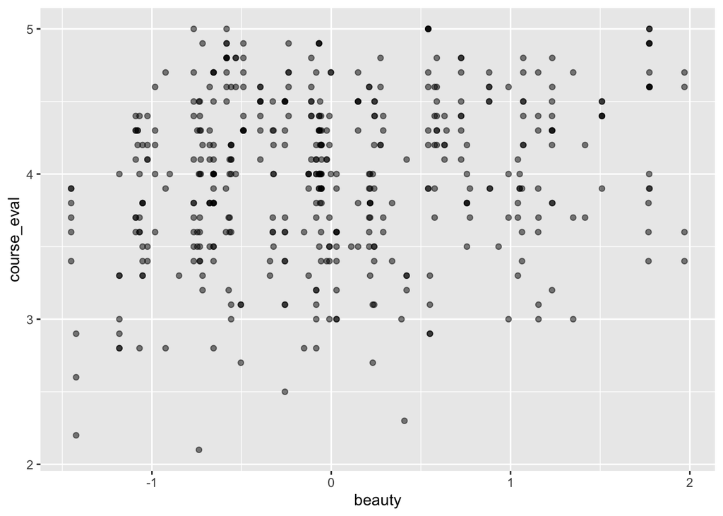

```r
data1 %>%
ggplot(aes(y =course_eval, x =beauty)) + geom_point(alpha = .5)
```

### 2. Run a regression of average course evaluations Course_Eval on the professor’s beauty Beauty

```r
model1 <- data1 %$% lm(course_eval ~ beauty)
summary(model1)
```

```
##
## Call:
## lm(formula = course_eval ~ beauty)
##
## Residuals:
##      Min       1Q   Median       3Q      Max
## -1.80015 -0.36304  0.07254  0.40207  1.10373
##
## Coefficients:
##             Estimate Std. Error t value Pr(>|t|)
## (Intercept)  3.99827    0.02535 157.727  < 2e-16 ***
## beauty       0.13300    0.03218   4.133 4.25e-05 ***
## ---
## Signif. codes:  0 '***' 0.001 '**' 0.01 '*' 0.05 '.' 0.1 ' ' 1
##
## Residual standard error: 0.5455 on 461 degrees of freedom
## Multiple R-squared:  0.03574,    Adjusted R-squared:  0.03364
## F-statistic: 17.08 on 1 and 461 DF,  p-value: 4.247e-05
```

- since the sample mean of the variable beauty is close to 0 and if the mean of residuals is also close to zero then the estimated intercept is close to the sample mean of dependent variable

### 3. Predict Professor Mori’s(one standard deviation above the average) and Professor Chen’s(an average value of Beauty) course evaluations

```r
mean_beauty = mean(data1$beauty)
std_beauty = sd(data1$beauty)
pf_chen_beauty <- data.frame(beauty=c(mean_beauty))
pf_mori_beauty <- data.frame(beauty=c(mean_beauty+std_beauty))


predict(model1, newdata=pf_chen_beauty)
```

```
##        1
## 3.998272
```

```r
predict(model1, newdata=pf_mori_beauty)
```

```
##        1
## 4.103163
```

### 4. control for course characteristics and professor characteristics

```r
model2 <- data1 %$% lm(course_eval ~ beauty+intro+onecredit+female+minority+nnenglish)
summary(model2)
```

```
##
## Call:
## lm(formula = course_eval ~ beauty + intro + onecredit + female +
##     minority + nnenglish)
##
## Residuals:
##      Min       1Q   Median       3Q      Max
## -1.84611 -0.33300  0.04912  0.37672  1.05872
##
## Coefficients:
##             Estimate Std. Error t value Pr(>|t|)
## (Intercept)  4.06829    0.03754 108.364  < 2e-16 ***
## beauty       0.16561    0.03073   5.389 1.14e-07 ***
## intro        0.01133    0.05448   0.208 0.835413
## onecredit    0.63453    0.11134   5.699 2.17e-08 ***
## female      -0.17348    0.04928  -3.520 0.000474 ***
## minority    -0.16662    0.07628  -2.184 0.029448 *
## nnenglish   -0.24416    0.10696  -2.283 0.022903 *
## ---
## Signif. codes:  0 '***' 0.001 '**' 0.01 '*' 0.05 '.' 0.1 ' ' 1
##
## Residual standard error: 0.5135 on 456 degrees of freedom
## Multiple R-squared:  0.1546, Adjusted R-squared:  0.1435
## F-statistic:  13.9 on 6 and 456 DF,  p-value: 1.529e-14
```

## brief conclusion

```r
summary(model1)$adj.r.squared
```

```
## [1] 0.0336441
```

- **2. after control other variables the coefficient of beauty increases by(%):**

```r
coef1 <- summary(model1)$coef[2, 1]
coef2 <- summary(model2)$coef[2, 1]
(coef2 - coef1) / coef1*100
```

```
## [1] 24.51741
```

- **it states that if we only consider the interest variables the estimation might be biased**
- **and the R-squared:**

```r
summary(model2)$adj.r.squared
```

```
## [1] 0.1435267
```

- the effect is still quite small

# [E2] heteroskedasticity

### 1. identify the difference in wages between men and women with the same characteristics

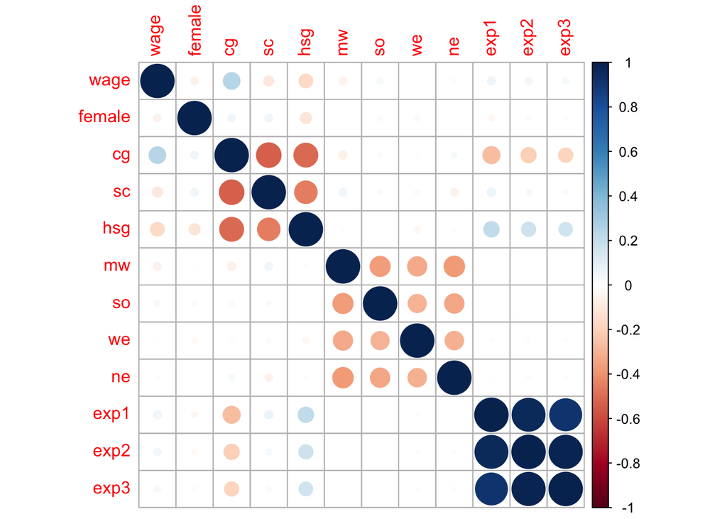

```r
target_controls <- select(data, wage, female, cg, sc, hsg, mw, so, we, ne, exp1, exp2, exp3)
cor_matrix <- cor(target_controls)
corrplot::corrplot(cor_matrix, method="circle")
```

```r
model1 <- lm(wage ~ female, data=data)
summary(model1)
```

```
##
## Call:
## lm(formula = wage ~ female, data = data)
##
## Residuals:
##    Min     1Q Median     3Q    Max
## -16.10  -5.93  -2.25   2.63 333.61
##
## Coefficients:
##             Estimate Std. Error t value Pr(>|t|)
## (Intercept)  16.1175     0.2858  56.394  < 2e-16 ***
## female       -1.3974     0.4421  -3.161  0.00158 **
## ---
## Signif. codes:  0 '***' 0.001 '**' 0.01 '*' 0.05 '.' 0.1 ' ' 1
##
## Residual standard error: 13.5 on 3833 degrees of freedom
## Multiple R-squared:  0.0026, Adjusted R-squared:  0.00234
## F-statistic: 9.993 on 1 and 3833 DF,  p-value: 0.001584
```

```r
model2 <- lm(wage ~ female+cg+hsg, data=data)
summary(model2)
```

```
##
## Call:
## lm(formula = wage ~ female + cg + hsg, data = data)
##
## Residuals:
##    Min     1Q Median     3Q    Max
## -19.87  -5.36  -1.97   2.83 329.55
##
## Coefficients:
##             Estimate Std. Error t value Pr(>|t|)
## (Intercept)  14.6179     0.4194  34.851  < 2e-16 ***
## female       -1.9059     0.4301  -4.431 9.64e-06 ***
## cg            6.0681     0.5053  12.008  < 2e-16 ***
## hsg          -1.9045     0.5369  -3.547 0.000394 ***
## ---
## Signif. codes:  0 '***' 0.001 '**' 0.01 '*' 0.05 '.' 0.1 ' ' 1
##
## Residual standard error: 13.06 on 3831 degrees of freedom
## Multiple R-squared:  0.068,  Adjusted R-squared:  0.06727
## F-statistic: 93.17 on 3 and 3831 DF,  p-value: < 2.2e-16
```

```r
model3 <- lm(wage ~ female+cg+hsg+mw+so+exp1+exp2, data=data)
summary(model3)
```

```
##
## Call:
## lm(formula = wage ~ female + cg + hsg + mw + so + exp1 + exp2,
##     data = data)
##
## Residuals:
##    Min     1Q Median     3Q    Max
## -20.51  -5.16  -1.62   2.75 325.55
##
## Coefficients:
##             Estimate Std. Error t value Pr(>|t|)
## (Intercept)   8.4979     0.8280  10.264  < 2e-16 ***
## female       -1.8356     0.4243  -4.326 1.56e-05 ***
## cg            7.2350     0.5143  14.066  < 2e-16 ***
## hsg          -2.4191     0.5319  -4.548 5.59e-06 ***
## mw           -1.0915     0.4934  -2.212    0.027 *
## so            0.5268     0.5194   1.014    0.311
## exp1          0.7618     0.0999   7.625 3.06e-14 ***
## exp2         -1.6528     0.2924  -5.653 1.69e-08 ***
## ---
## Signif. codes:  0 '***' 0.001 '**' 0.01 '*' 0.05 '.' 0.1 ' ' 1
##
## Residual standard error: 12.87 on 3827 degrees of freedom
## Multiple R-squared:  0.09503,    Adjusted R-squared:  0.09337
## F-statistic: 57.41 on 7 and 3827 DF,  p-value: < 2.2e-16
```

```r
model4 <- lm(wage ~ female+cg+hsg+mw+so+exp1+exp2+exp3, data=data)
summary(model4)
```

```
##
## Call:
## lm(formula = wage ~ female + cg + hsg + mw + so + exp1 + exp2 +
##     exp3, data = data)
##
## Residuals:
##    Min     1Q Median     3Q    Max
## -20.78  -5.13  -1.62   2.73 325.55
##
## Coefficients:
##             Estimate Std. Error t value Pr(>|t|)
## (Intercept)   7.2907     1.2284   5.935 3.20e-09 ***
## female       -1.8230     0.4244  -4.296 1.79e-05 ***
## cg            7.3900     0.5273  14.014  < 2e-16 ***
## hsg          -2.4757     0.5336  -4.640 3.61e-06 ***
## mw           -1.1006     0.4934  -2.231   0.0257 *
## so            0.5178     0.5194   0.997   0.3189
## exp1          1.0937     0.2688   4.069 4.82e-05 ***
## exp2         -3.9947     1.7846  -2.238   0.0253 *
## exp3          0.4569     0.3435   1.330   0.1835
## ---
## Signif. codes:  0 '***' 0.001 '**' 0.01 '*' 0.05 '.' 0.1 ' ' 1
##
## Residual standard error: 12.87 on 3826 degrees of freedom
## Multiple R-squared:  0.09545,    Adjusted R-squared:  0.09356
## F-statistic: 50.46 on 8 and 3826 DF,  p-value: < 2.2e-16
```

- model identification
1. after drawing the heat map I think cg, hsg, sc need to be controlled but if all of them has controlled there will be perfect collinearity so only add sg, hsg
2. do some trials and add more controlled variables: mw, so, exp1, exp2, exp3
3. conclusion: the effect=-1.8230

### 2. Estimate the heteroskedasticity-robust standard error

- standard error with the assumption: homoskedasticity

```r
summary(model4)$coef[, 2]
```

```
## (Intercept)      female          cg         hsg          mw          so
##   1.2284383   0.4243874   0.5273347   0.5335844   0.4933536   0.5193999
##        exp1        exp2        exp3
##   0.2688231   1.7846419   0.3434829
```

### 3. robust command

```r
model5 <- lm_robust(wage ~ female+cg+hsg+mw+so+exp1+exp2+exp3, data=data)
summary(model5)$coef[, 2]
```

```
## (Intercept)      female          cg         hsg          mw          so
##   1.5643046   0.4359517   0.6666569   0.2779128   0.4868127   0.5510073
##        exp1        exp2        exp3
##   0.2732417   1.6119157   0.2893662
```

### 4. bootstrap standard error

```r
B <- 1000
betas <- c()
for (b in 1:B) {
  samp_b <- sample.int(nrow(data), replace=TRUE)
  reg_b <- lm(wage ~ female+cg+hsg+mw+so+exp1+exp2+exp3, data=data[samp_b,])
  betas <- rbind(betas, coef(reg_b))
}
apply(betas, 2, sd)
```

```
## (Intercept)      female          cg         hsg          mw          so
##   1.5412291   0.4267148   0.6468077   0.2735795   0.4881235   0.5376525
##        exp1        exp2        exp3
##   0.2693618   1.5862695   0.2846632
```

### code reference

- [more information](https://gitlab.com/gitlabjacky/causal_ml_r101/-/tree/main/economic_analysis_using_R)